# The Basic Use of REGEX in Bioinformatics

yingying

November 20, 2018

## Task

1. Understand important concepts and tools: “regular expression”, “grep”, “sed”, “awk”
2. Use what we learn to extarct information from genome or annotation files
3. Example: extract protein coding transcriptID geneID and gene names from .gtf file

## Regular expressions

A regular expression is a pattern that describes a set of strings. Regular expressions are constructed analogously to arithmetric expressions by using various operators to combine smaller expressions.

The fundamental building blocks are the regular expressions that match a single character. Most characters, including all letters and digits, are regular expressions that match themselves. Any metacharacter with special meaning may be quoted by preceding it with a backslash.

## grep

### What is grep?

grep searches the input files for lines containing a match to a given pattern list. When it finds a match in a line, it copies the line to standard output (by default), or whatever other sort of output you have requested with options.

Though grep expects to do the matching on text, it has no limits on input line length other than available memory, and it can match arbitrary characters within a line. If the final byte of an input file is not a newline, grep silently supplies one. Since newline is also a separator for the list of patterns, there is no way to match newline characters in a text.

### Basics of grep

```bash
# looking for gene entries in annotation file
grep -i 'sox9' org_abc_ensembl.gtf | head -n 3 # -i --ignore-case
```

```bash
# Extract the reads from a .fa which contain a specific nucleotide sequence
# -B NUM, –before-context NUM
# -A NUM, –after-context NUM

grep -B 1 -A 2 -i 'ccggaacgccggcggc' org_abc_ensembl.fa
```

```bash
# number of protein-coding transcripts
grep -c protein_coding org_abc_ensembl.fa

# number of non-protein-coding transcripts
grep -cv protein_coding org_abc_ensembl.fa

#-v, –invert-match  returns lines that do NOT contain your pattern.
#-c print the number of matches
```

```bash
grep "^>" org_abc_ncbi.fna | cut -c1-3 | sort | uniq -c
# cut -c1-3 cut out the first three letters
# sort the data and then send it to the “uniq” command to keep only the unique occurences of the letters. The “-c” option counts up the number of occurences
```

## sed

### What is sed?

A Stream EDitor is used to perform basic transformations on text read from a file or a pipe. The result is sent to standard output. The syntax for the sed command has no output file specification, but results can be saved to a file using output redirection. The editor does not modify the original input.

What distinguishes sed from other editors, such as vi and ed, is its ability to filter text that it gets from a pipeline feed. You do not need to interact with the editor while it is running; that is why sed is sometimes called a batch editor. This feature allows use of editing commands in scripts, greatly easing repetitive editing tasks. When facing replacement of text in a large number of files, sed is a great help.

### Basics of sed

```bash
sed -n '/SOX9/'p org_abc_ensembl.gtf | head -3
# Perform exactly like grep 'SOX9' org_abc_ensembl.gtf | head -n 3
# without -n sed prints the entire file, but the lines containing the search string are printed twice
```

```bash
sed -n '/lnc_RNA/p' org_abc_ncbi.gff | wc -l # number of lnc_RNA
```

```bash
# delete lnc_RNA
# not run
# sed -n '/lnc_RNA/d' org_abc_ncbi.gff
```

```bash
# find erors and replace them with errors
#sed 's/erors/errors/g' example

# multiple replacement
#sed -e 's/erors/errors/g' -e 's/last/final/g' example

# without g only the first occurrence of the search string in each line can be replaced
```

## awk

### What is awk?

Gawk is the GNU version of the commonly available UNIX awk program, another popular stream editor.

Since the awk program is often just a link to gawk, we will refer to it as awk.

The basic function of awk is to search files for lines or other text units containing one or more patterns. When a line matches one of the patterns, special actions are performed on that line.

Programs in awk are different from programs in most other languages, because awk programs are “data-driven”: you describe the data you want to work with and then what to do when you find it. Most other languages are “procedural.” You have to describe, in great detail, every step the program is to take. When working with procedural languages, it is usually much harder to clearly describe the data your program will process. For this reason, awk programs are often refreshingly easy to read and write.

Back in the 1970s, three programmers got together to create this language. Their names were Aho, Kernighan and Weinberger. They took the first character of each of their names and put them together. So the name of the language might just as well have been “wak”.

### Basics of awk

#### 1. awk print command line: print selected fileds

The print command in awk outputs selected data from the input file.

awk ‘EXPRESSION { PROGRAM }’ file(s)

When awk reads a line of a file, it divides the line in fields based on the specified input field separator, FS, which is an awk variable (see Section 6.3.2). This variable is predefined to be one or more spaces or tabs.

The variables $1, $2, $3, …, $N hold the values of the first, second, third until the last field of an input line.

The variable $0 (zero) holds the value of the entire line.

```bash
ls -l | awk '{ print $5 $9 }'
#print the 5th and 9th colimn of a long file listing which have 9 columns
```

#### 2. The input and output field separator

The field separator, which is either a single character or a regular expression, controls the way awk splits up an input record into fields. The input record is scanned for character sequences that match the separator definition; the fields themselves are the text between the matches.

The field separator is represented by the built-in variable FS.

The value of the field separator variable can be changed in the awk program with the assignment operator =.

Often the right time to do this is at the beginning of execution before any input has been processed, so that the very first record is read with the proper separator. To do this, use the special BEGIN pattern.

```bash
awk 'BEGIN { FS=":" } { print $1 "\t" $5 }' /etc/passwd | tail -3
#assign the field separator variable with ":"
#the output field separator is assigned to "\t", if none, print will treat the items to output as one argument, thus omitting the use of the default output separator, OFS
```

```bash
awk 'BEGIN { FS=":"; OFS=";" ; ORS="\n------->done\n" } { print "Record number" NR ":\t" $1, $5} \
END {print "Number of records processed: " NR}' /etc/passwd | tail -5

#The output from an entire print statement is called an output record. Each print command results in one
#output record, and then outputs a string called the output record separator, ORS. The default value for this variable is "\n", a newline character. Thus, each print statement generates a separate line.
#To change the way output fields and records are separated, we can assign new values to OFS and ORS
```

#### 3. The number of records

The built-in NR holds the number of records that are processed. It is incremented after reading a new input line. You can use it at the end to count the total number of records, or in each output record

#### 4. awk scripts

As commands tend to get a little longer, you might want to put them in a script, so they are reusable. An awk script contains awk statements defining patterns and actions.

```bash
cat example_fs.awk
awk -f example_fs.awk /etc/passwd | tail -5
```

## Example

extract protein coding transcriptID geneID and gene names from .gtf and .gff files

The gtf file has 9 columns. The first 8 are separated by tabs (chromosome, annotation source, feature type, start, end, score, strand, and phase). The last column is made up of key-value pairs separated by semicolons, some fields are mandatory and others are optional, and the values are surrounded in double quotes.

```bash
#see the detailed information stored in .gtf files
less -S org_abc_ensembl.gtf
```

```bash
grep -v "#" org_abc_ensembl.gtf | cut -f 3 | sort | uniq -c | sort
```

```bash
grep -v "#" org_abc_ncbi.gff | cut -f 3 | sort | uniq -c | sort
```

```bash
#set field separator with tab "\t" ; by default AWK uses whitespace as the delimiter between columns but there are two types of whiteshapce: space and tabs
#make sure column 3 is a transcript and make use of the information from column 9

awk 'BEGIN {OFS=FS="\t"} $3 == "transcript" { print $9 }' org_abc_ensembl.gtf | head | less -S

#or
awk -F "\t" '$3 == "transcript" { print $9 }' org_abc_ensembl.gtf | head | less -S
```

```bash
#pipe the results from the last step
# delete all the semicolons and quotes before
#and get the gene id after getting the protein coding transcripts
awk -F "\t" '$3 == "transcript" { print $9 }' org_abc_ensembl.gtf | \
tr -d ";\"" | \
awk -F " " ' $20 == "protein_coding" { print $2, $6, $10}' > transcript2gene.txt
```

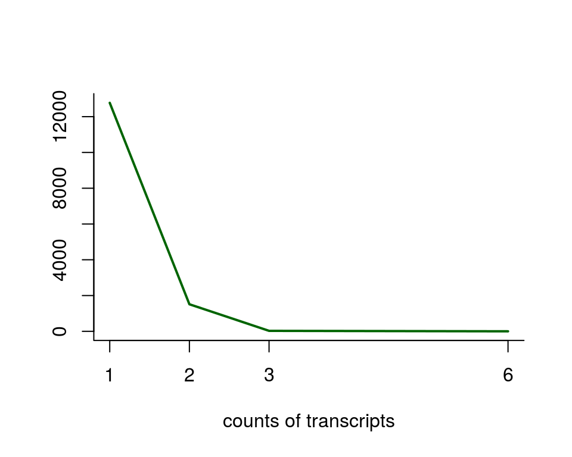

```r
t2g<-read.table(file = "transcript2gene.txt",
                sep = " " )
tcg2<-as.data.frame(table(t2g$V1))
plot(table(tcg2$Freq),type = "l", col = "darkgreen", main = "", xlab = "counts of transcripts", ylab = "", bty = "l")
```